# Lab Module: Interactive Plots & Tables

### Side-by-side bar charts / Demographic Pyramid

Next, let’s do a chart that we haven’t explicitly covered before: side-by-side bar charts, or what population graphs are usually comprised of! The R for Epidemiologist Handbook and other resources also refer to this as a **Demographic Pyramid**. I’m referencing these posts for the following code:

Cut for R (make categories of AQI values): https://r-coder.com/cut-r/ Population Pyramid in ggplot: https://stackoverflow.com/questions/14680075/simpler-population-pyramid-in-ggplot2 Skipping discrete labels: https://stackoverflow.com/questions/66275692/r-skip-labels-in-discrete-x-axis R Epidemiologist Handbook Chapter 33: https://epirhandbook.com/en/demographic-pyramids-and-likert-scales.html

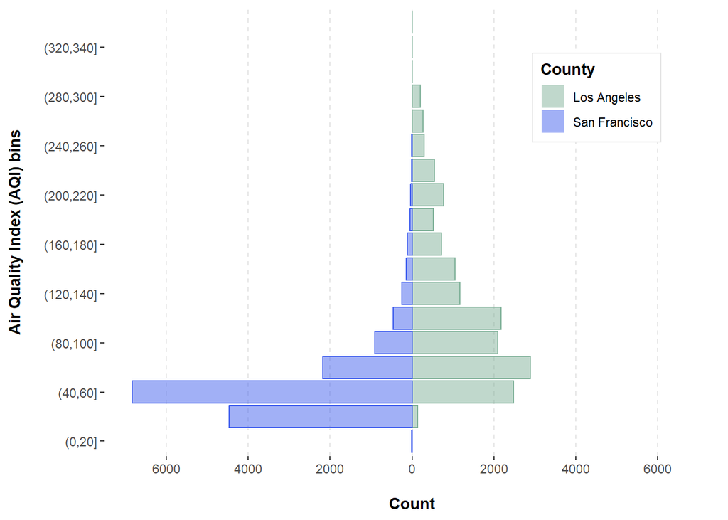

```r
#create dataset for side-by-side barchart of AQI values, done without geometry
aqi_cut_cat <- st_drop_geometry(ca_aqi_geo) %>%
  #create categories with breaks every 20 units of AQI
  mutate(aqi_cat = cut(ca_aqi_geo$aqi, breaks = seq(0, 600, 20))) %>%
  #group by county and AQI category
  group_by(county, aqi_cat) %>%
  #get number of counts in each county-aqi category combination
  summarise(n = n()) %>%
  #filter out NAs in aqi_cat (when they're larger than 600)
  filter(is.na(aqi_cat) == F)
#filter dataset to be SF and LA counties
aqi_sbs_plot <- ggplot(data = aqi_cut_cat %>% filter(county %in% c("San Francisco", "Los Angeles")),
       #if county is SF, make the counts "negative"
       mapping = aes(x = ifelse(test = county == "San Francisco", yes = -n, no = n),
                     #y axis will be the categories, encoding by county
                     y = aqi_cat, color = county, fill = county)) +
  geom_col(alpha = 0.5, size = 0.5) +
  #absolute value for labels on the x axis (so negative counts will be positive!); 10 breaks in total
  scale_x_symmetric(labels = abs, n.breaks = 10) +
  #Take every first label (TRUE), skip every second label (FALSE)
  scale_y_discrete(breaks = function(x){x[c(TRUE, FALSE)]}) +
  #give manual color choices
  scale_fill_manual(values = c("#81b29a", "#4361ee")) +
  scale_color_manual(values = c("#81b29a", "#4361ee")) +
  #remove background fill
  theme(panel.background = element_rect(fill = NA),
        #remove y gridlines
        panel.grid.major.y = element_blank(),
        #emphasize major x gridlines
        panel.grid.major.x = element_line(color = "grey90", linetype = "dashed"),
        #remove minor x gridlines
        panel.grid.minor.x = element_blank(),
        #bold axis and legend titles
        axis.title = element_text(face = "bold"),
        legend.title = element_text(face = "bold"),
        #modify legend position and background
        legend.position = c(0.8, 0.8),
        legend.background = element_rect(color = "grey90")) +
  #remove legend for color (duplicates fill)
  guides(color = "none") +
  #custom lables
  labs(x = "\nCount",
       y = "Air Quality Index (AQI) bins\n",
       fill = "County")

aqi_sbs_plot
```

```r
#what does the native ggplotly conversion look like?
ggplotly(aqi_sbs_plot)
```

[interactive chart not shown]

Again, the `ggplotly` conversion looks so good that I am not very tempted to recreate a native `plotly` object, and some exploration online to find out how to do so suggests the relative difficulty of such a task. Therein lies the strength of `ggplot` and `plotly` working harmoniously through `ggplotly` – missing or to-be-developed features in `plotly` do not necessarily need to be given up if you can make do with some workarounds in `ggplot.`

Let’s modify the hover text of the chart above for `ggplotly`, just to round out a HTML/webpage ready visualization. These more complex visualizations with comparison usage scenarios are really where interactivity can shine!

```r
#filter dataset to be SF and LA counties
aqi_sbs_plot_2 <- ggplot(data = aqi_cut_cat %>% filter(county %in% c("San Francisco", "Los Angeles")),
       #if county is SF, make the counts "negative"
       mapping = aes(x = ifelse(test = county == "San Francisco", yes = -n, no = n),
                     #y axis will be the categories, encoding by county
                     y = aqi_cat, color = county, fill = county,
                     text = paste("County:", county,
                                  "\nAQI Category:", aqi_cat,
                                  "\nCount:", abs(n)))) +
  geom_col(alpha = 0.5, size = 0.5) +
  #absolute value for labels on the x axis (so negative counts will be positive!); 10 breaks in total
  scale_x_symmetric(labels = abs, n.breaks = 10) +
  #Take every first label (TRUE), skip every second label (FALSE)
  scale_y_discrete(breaks = function(x){x[c(TRUE, FALSE)]}) +
  #give manual color choices
  scale_fill_manual(values = c("#81b29a", "#4361ee")) +
  scale_color_manual(values = c("#81b29a", "#4361ee")) +
  #remove background fill
  theme(panel.background = element_rect(fill = NA),
        #remove y gridlines
        panel.grid.major.y = element_blank(),
        #emphasize major x gridlines
        panel.grid.major.x = element_line(color = "grey90", linetype = "dashed"),
        #remove minor x gridlines
        panel.grid.minor.x = element_blank(),
        #bold axis and legend titles
        axis.title = element_text(face = "bold"),
        legend.title = element_text(face = "bold"),
        plot.title = element_text(face = "bold"),
        #modify legend position and background
        legend.position = c(0.8, 0.8),
        legend.background = element_rect(color = "grey90")) +
  #remove legend for color (duplicates fill)
  guides(color = "none") +
  #custom lables
  labs(x = "\nCount",
       y = "Air Quality Index (AQI) bins\n",
       fill = "County",
       title = "Comparing AQI distributions across SF and LA counties")

ggplotly(aqi_sbs_plot_2, tooltip = "text")
```

[interactive chart not shown]

### Bubble charts

Next, let’s take a look at bubble charts. The principles here can be extended to conventional scatterplots. Again, interactivity here is really useful – you can easily take a look at outliers in your EDA process, and these graphs can be more accessible and immediately actionable to a lay audience viewing your interactive report. I’d like to focus on making sure, as we have with the previous plots, that we pay attention to classic data visualization principles however – we still run the risk of overplotting, and we should ensure that hover texts are clear, legible, and present relevant information.

Below, we take a look at AQI and population (two continuous variables) at the city-region level, with differential sizing of dots by population density. You may notice that our first plot is very busy on the left-hand side – many observations (in this case, city-regions) sit along a smaller population size. There’s a few outliers on the right-hand side that can be explored immediately using `plotly`, as we’ll see in a bit.

What’s a strategy we can use to address this overplotting on the left-hand side while still preserving the general relationships we see in these data? This may be covered more in biostatistics courses, but you can *transform* variables to normalize and/or linearize the relationships between variables. There are some benefits (and drawbacks) in terms of model fitting and interpretation of results, but for now, we’ll operate on the knowledge that transforming variables is an existing practice and can be a viable tool in data visualization as well!

Also in the spirit of sharing the visualization thought process, here are some search strings I used while making these plots and the links that eventually helped:

- “exponents ggplot2 labels”: https://stackoverflow.com/questions/33149505/adding-exponent-to-axes-labels-r-ggplot2
- “non scientific labels ggplot axis”: https://stackoverflow.com/questions/14563989/force-r-to-stop-plotting-abbreviated-axis-labels-scientific-notation-e-g-1e

[figure not shown]

```r
#make our dataset
data_bubble <- ca_aqi %>%
  #group by city-region
  group_by(city_ascii) %>%
  #create weighted AQI measure, mean of population, mean of density
  summarise(aqi = weighted.mean(aqi, population),
            population = mean(population),
            density = mean(density))

ggplot(data = data_bubble, aes(x = population, y = aqi)) +
  #bubbles are symbolized dynamically in color and size by density
  geom_point(aes(size = density, color = density)) +
  #change x axis labels from scientific to commas
  scale_x_continuous(labels = scales::comma) +
  #use viridis color palette
  scale_color_viridis_c()+
  #set the range of sizes that bubbles can take on
  scale_size(range = c(1, 20),
             #we also scale the size (driven by density) by cubing it, emphasizing larger values
             trans = scales::trans_new(name = "cube",
                                       transform = function(x) x**3,
                                       inverse = function(x) x**3)) +
  #add stata theme (from ggthemes package)
  theme_stata() +
  #take out size legend
  guides(size = "none") +
  #increase width of color legend
  theme(legend.key.width = unit(1.85, "cm")) +
  #labels
  labs(color = expression(paste("Density (person per ", km^{2}, ")")),
       x = "\nPopulation Size (natural log)",
       y = "AQI\n (population weighted average) \n")
```

The results are interesting, and don’t look half-bad, especially with the preset Stata theme. To address the overplotting on the left-hand side, however, we’re going to perform a log-transformation on `population`, the x-axis. Remembering back to our algebra roots, this translates to very large values shrinking down, and very small units will increase in relative size. In general, log-transformations are great for skewed data, which we have here with the `population` variable. Take a look at the difference:

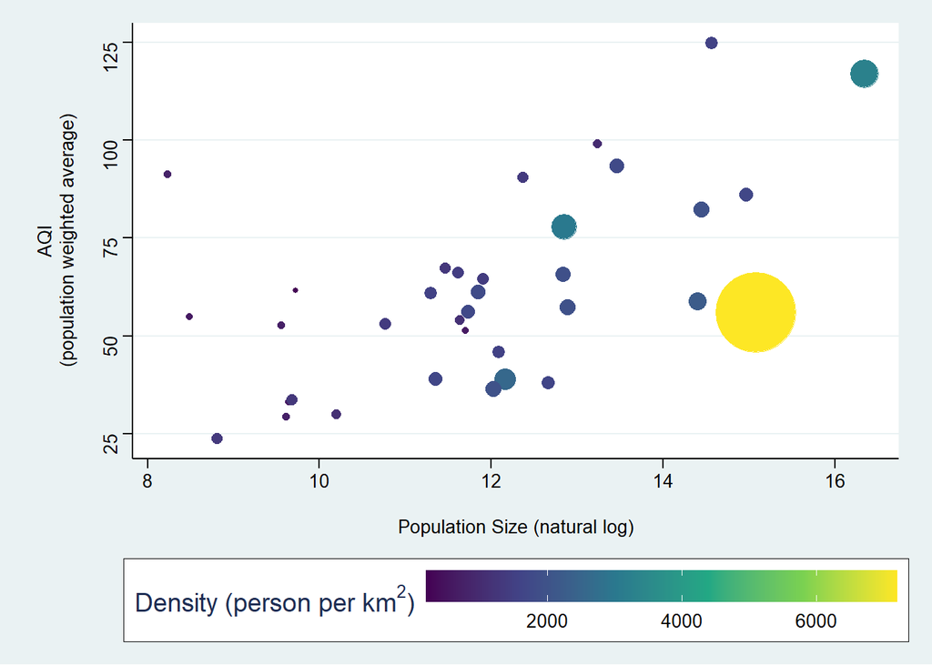

```r
#lets make a static ggplot, now with a log-transformation for population --
aqi_bubble <- ggplot(data = data_bubble, aes(x = log(population), y = aqi)) +
  geom_point(aes(size = density, color = density)) +
  scale_x_continuous(labels = scales::comma) +
  scale_color_viridis_c()+
  scale_size(range = c(1, 20),
             trans = scales::trans_new(name = "cube",
                                       transform = function(x) x**3,
                                       inverse = function(x) x**3)) +
  theme_stata() +
  guides(size = "none") +
  theme(legend.key.width = unit(1.80, "cm")) +
  labs(color = expression(paste("Density (person per ", km^{2}, ")")),
       x = "\nPopulation Size (natural log)",
       y = "AQI\n (population weighted average) \n")

aqi_bubble
```

The general plot looks a lot less crowded on the left-hand side! This transformation also now suggests a fairly linear relationship between the natural log of population size and AQI measures, which may or may not be true. This should be taken into consideration when using transformations in any analysis or visualization. Further, we want to emphasize the interpretability of log (or any) transformations – it can be confusing for many audiences and should be reserved for those who may be familiar with the practice (showing EDA to your biostatistics advisor, for example).

Next, we’ll convert the `ggplot` object we just made using `ggplotly.`

```r
#convert into a plotly object using ggplotly
ggplotly(aqi_bubble)
```

[interactive chart not shown]

You’ll notice that this conversion isn’t the most successful – most things carry over, but the font became serif from sans serif, the legend for city is still present, and the legend for density has an incorrect title. However, it is still convenient to explore the outliers (Riverside, Los Angeles, for example), using the plot.

Let’s try to make an alternative with native `plotly`.

Here’s the `plotly` page for bubble charts: https://plotly.com/r/bubble-charts/

```r
#plotly object reference same dataset as before
plot_ly(data_bubble,
        x = ~log(population),
        y = ~aqi,
        color = ~density,
        #next two lines define scatterplot
        type = 'scatter',
        mode = 'markers',
        #inclusion of size argument makes it a bubble chart, here we scale by x^3 for clarity
        size = ~density**3,
        #range of sizes that bubbles can take on
        sizes = c(10, 2500),
        #give bubbles transparency/alpha of 0.75
        marker = list(opacity = 0.75),
        hoverinfo = 'text',
        #custom hover text, <b> text </b> means bolded text
        text = ~paste("<b>City/Region:</b>", city_ascii,
                      #<br> means a newline, or break, here we round aqi to 2 digits
                      "<br><b>AQI (pop-weighted mean):</b>", round(aqi, 2),
                      "<br><b>Population:</b>", population,
                      "<br><b>Density (people per sq km):</b>", density)) %>%
  #like ggplot, different parts of the layout get identical arguments
  layout(xaxis = list(showgrid = FALSE, title = "Population size (natural log)",
                      #give border lines for x axis
                      linecolor = "black", linewidth = 1),
         yaxis = list(title = "AQI \n(population-weighted average)",
                      linecolor = "black", linewidth = 1),
         #remove legend for size
         showlegend = FALSE,
         #background color
         paper_bgcolor = 'rgb(225, 240, 245)',
         #custom font
         font = list(family = "Arial", size = 12)) %>%
  #title of color legend
  colorbar(title = "Density \n(people per sq km)")
```

[interactive chart not shown]

With these modifications annotated in the code, I’m reasonable happy with the parity between this `plotly` graph and `ggplot` original. I prefer the scaling of the `plotly` plot, which accentuates how much more dense San Francisco is compared to peer city/regions (and the sans serif font). You can achieve the same using `scales::`. Of course, as you can throughout any module, feel free to modify code as you go along to see how it affects your final visualization – it’s the best way to learn!

## Alternative graphing library: ggigraph

`ggigraph` is a newer graphing library that, likely `ggplotly`, also attempts to bridge `ggplot2` objects with interactivity. It offers some features that should be interesting to implement for interactive documents, like linked units across graphs (which will be showcased shortly). From their documentation, the necessary syntax adjustments we’d like to make aside from our standard `ggplot2` syntax include:

- add `_interactive` to the geom names (for example, change `geom_point` to `geom_point_interactive`)
- add `tooltip`, `data_id`, or both to the `aes` function
- `tooltip`: what is displayed when hovering over a graphic element
- `data_id`: unique IDs for units that we’d like to assign linked interactivity to
- render the plot with the girafe function (note the spelling)

Let’s extend the graphs we’ve already made by making a combined plot of AQI trends over time and population density bubble charts.

```r
#let's copy our lineplot from before, with some additions
lineplot_igraph <- ggplot(data = aqi_lineplot, aes(x = date, y = aqi, color = county,
                                                   #note we add these two arguments to indicate the hover text
                                                   #and the interactive grouping
                                                   data_id = county, tooltip = county)) +
  #add a line connecting observations NOTING that it is _interactive
  geom_line_interactive() +
  #can add geom_point if you'd like, may not be as legible
  #geom_point(alpha = 0.5) +
  #add horizontal reference line at the weighted mean of aqi values
  geom_hline(yintercept = mean(aqi_lineplot$aqi),
             color = "gray25", linetype = "dashed", linewidth = 0.75) +
  #start x axis at 0
  scale_x_date(expand = c(0,0)) +
  #give gridlines color grey at 98% transparency/alpha
  theme(panel.grid = element_line(color = "grey98"),
        #give custom x and y axis lines at 70% grey, size 0.5
        axis.line = element_line(color = "grey70", linewidth = 0.5),
        #give axis ticks that push into the plot instead of out
        axis.ticks.length = unit(-0.25, "cm"),
        #indicate x axis ticks
        axis.ticks.x = element_line(color = "grey40", linewidth = 0.5),
        #make white background
        panel.background = element_rect(fill = "grey100", color = "grey100", linewidth = 0.5),
        #give custom position for legend
        legend.position = c(0.70,0.95),
        #bold plot title
        plot.title = element_text(face="bold")) +
  #customize legend for color, all contained in 1 row, and actual lines in legend are size 6
  guides(color = guide_legend(nrow = 1,
                              byrow = TRUE,
                              override.aes = list(size = 6)))+
  #give legends. \n indicates newlines, which spaces out the titles
  labs(x = "\nYears",
       y = "Air Quality Index (AQI) values \n",
       color = "",
       caption = "Horizontal reference line indicates average AQI value \n Data courtesy Environmental Protection Agency (EPA)",
       title = "Time trends of Air Quality Index (AQI) values for Bay Area counties\n")

#we call the igraph object with the following function:

girafe(ggobj = lineplot_igraph,
       #these options simply indicate we'd like the colors to extend to the hover
       #by default, the hover has white text on a black background
       options = list(opts_tooltip(use_fill = TRUE)))
```

[interactive chart not shown]

```r
#next, let's do the same with the population density against aqi scatterplot (we're not able to make bubble charts with ggigraph, yet)
aqi_scatter_igraph <- ggplot(data = aqi_lineplot %>%
                              group_by(county) %>%
                              summarise(aqi = weighted.mean(aqi, pop),
                                        population = mean(pop)), aes(x = log(population), y = aqi,
                                                    #remember our additions
                                                    data_id = county, tooltip = county)) +
  #remember to make our geom interactive
  geom_point_interactive() +
  scale_x_continuous(labels = scales::comma) +
  scale_color_viridis_c()+
  scale_size(range = c(1, 20),
             trans = scales::trans_new(name = "cube",
                                       transform = function(x) x**3,
                                       inverse = function(x) x**3)) +
  theme_stata() +
  guides(size = "none") +
  #theme(legend.key.width = unit(1.80, "cm")) +
  labs(color = expression(paste("Density (person per ", km^{2}, ")")),
       x = "\nPopulation Size (natural log)",
       y = "AQI\n (population weighted average) \n")


#next, we call our ggigraph object

girafe(ggobj = aqi_scatter_igraph,
       options = list(opts_tooltip(use_fill = TRUE)))
```

[interactive chart not shown]

This was a brief introduction to ggigraph, but hopefully it illustrates the potential to combine graphs and cross-reference the same units. Since it is still a new package, however, visual customization is limited (note how we were not able to symbolize geom_point_interactive by a dynamic size).

## Interactive Tables in R

While this course has not devoted much time to visualizing tables, based on the assumption that you have covered table construction in your stats courses, they are intrinsically tied into communicating data. In any public health practice that involves data, tables are just as important as visualizations (and in some cases, even more so!). This section aims to give a quick overview of interactive tables that R users can leverage in interactive reports.

**A note on accessibility**: A neat thing about both `dt` and `reactable` is that since both generate a HTML table, the resulting output(s) should be compatible with screen readers, making your interactive documents accessible to a wider audience!

We’ll be exploring these two packages:

**DT / datatables**: A venerated javascript library for interactive tables https://rstudio.github.io/DT/

**reactable**: A newer library in development, with simpler syntax: https://glin.github.io/reactable/index.html

Let’s start first with **datatables**! We’ll be using the same dataset that we made for the bubble chart, for ease.

```r
#wrapping our dataset in the datatable function to start
datatable(data_bubble)
```

|  | city_ascii | aqi | population | density |
| --- | --- | --- | --- | --- |
| 1 | Bakersfield | 99.06804484479295 | 556892 | 979 |
| 2 | Bishop | 91.39006074924063 | 3747 | 776 |
| 3 | Chico | 54.08658854166666 | 113201 | 1116 |
| 4 | Clearlake | 33.1435219531935 | 15329 | 584 |
| 5 | Crescent City | 23.68431029454651 | 6690 | 1315 |
| 6 | El Centro | 66.17278558755288 | 110434 | 1430 |
| 7 | Eureka | 29.9822409607768 | 26938 | 1090 |
| 8 | Fresno | 93.55074057305478 | 702486 | 1763 |
| 9 | Hanford | 67.31824079765076 | 95459 | 1272 |
| 10 | Los Angeles | 116.9595202398801 | 12531334 | 3267 |

[output cut: 25 more lines]

The default result is usable! As you can test for yourself, it’s an interactive paginated version of what our data viewer in R is, but it’ll stay interactive when knit to an HTML file! There’s a few options for customization and improvement we can explore.

Let’s first start with some **visual changes**:

```r
datatable(data_bubble,
          #add CSS class for theming
          class = 'cell-border stripe',
          #remove numbered index
          rownames = F,
          #add custom column names instead of renaming columns
          colnames = c("City/Region", "AQI (population-weighted average)",
                       "Population", "Density (people per sq. km)")) %>%
  #bold the `city_ascii` column
  formatStyle("city_ascii", fontWeight = "bold") %>%
  #round the `aqi` column to one decimal place
  formatRound("aqi", 1) %>%
  #format the `aqi` column to have red text over values of 75, black otherwise
  formatStyle(c("aqi"),
              color = styleInterval(c(75), c("black", "red")),
              #bold values over 75, normal weight otherwise
              fontWeight = styleInterval(c(75), c("normal", "bold")))
```

| City/Region | AQI (population-weighted average) | Population | Density (people per sq. km) |
| --- | --- | --- | --- |
| Bakersfield | 99.06804484479295 | 556892 | 979 |
| Bishop | 91.39006074924063 | 3747 | 776 |
| Chico | 54.08658854166666 | 113201 | 1116 |
| Clearlake | 33.1435219531935 | 15329 | 584 |
| Crescent City | 23.68431029454651 | 6690 | 1315 |
| El Centro | 66.17278558755288 | 110434 | 1430 |
| Eureka | 29.9822409607768 | 26938 | 1090 |
| Fresno | 93.55074057305478 | 702486 | 1763 |
| Hanford | 67.31824079765076 | 95459 | 1272 |
| Los Angeles | 116.9595202398801 | 12531334 | 3267 |

[output cut: 25 more lines]

Next, let’s look at some functional customizations:

```r
datatable(data_bubble,
          #add CSS class for theming
          class = 'cell-border stripe',
          #remove numbered index
          rownames = F,
          #add custom column names instead of renaming columns
          colnames = c("City/Region", "AQI (population-weighted average)",
                       "Population", "Density (people per sq. km)"),
          #add buttons to export the data within the html (cool!)
          #note that the `dom` argument can accept many, check out documentation for more
          #by calling `Btp`, we keep buttons (B), the table itself (t), and pagination control (p)
          extensions = 'Buttons', options = list(dom = 'Btpl',
                                                 buttons = c('copy',
                                                             'csv',
                                                             'excel',
                                                             'pdf',
                                                             'print'),
                                                 #how many entries per page
                                                 pageLength = 10,
                                                 #options for "Show how many entries"
                                                 lengthMenu = c(10, 20, 30))) %>%
  #bold the `city_ascii` column
  formatStyle("city_ascii", fontWeight = "bold") %>%
  #round the `aqi` column to one decimal place
  formatRound("aqi", 1) %>%
  #format the `aqi` column to have red text over values of 75, black otherwise
  formatStyle(c("aqi"),
              color = styleInterval(c(75), c("black", "red")),
              #bold values over 75, normal weight otherwise
              fontWeight = styleInterval(c(75), c("normal", "bold")))
```

| City/Region | AQI (population-weighted average) | Population | Density (people per sq. km) |
| --- | --- | --- | --- |
| Bakersfield | 99.06804484479295 | 556892 | 979 |
| Bishop | 91.39006074924063 | 3747 | 776 |
| Chico | 54.08658854166666 | 113201 | 1116 |
| Clearlake | 33.1435219531935 | 15329 | 584 |
| Crescent City | 23.68431029454651 | 6690 | 1315 |
| El Centro | 66.17278558755288 | 110434 | 1430 |
| Eureka | 29.9822409607768 | 26938 | 1090 |
| Fresno | 93.55074057305478 | 702486 | 1763 |
| Hanford | 67.31824079765076 | 95459 | 1272 |
| Los Angeles | 116.9595202398801 | 12531334 | 3267 |

[output cut: 25 more lines]

This is only a survey of a very few functions available in datatable, so do check out the aforementioned documentation to learn more!

Now, let’s move onto **reactable**:

Again, `reactable` is a newer library and may offer simpler construction and more flexibility than `dt`. It still is in development however, so documentation and help may not be as available.

For this, we’ll use the dataset we used for the earlier lineplot to showcase convenient functionality to group table entries by a categorical variable (in this case, grouping observations each year by county).

```r
#subset out an unneeded column, groupby county
reactable(aqi_lineplot %>% select(-date), groupBy = 'year',
          #rename first column
          columns = list(county = colDef(name = "County"),
                         #rename second column
                         year = colDef(name = "Year"),
                         #rename third column, rounding to 1 digit
                         aqi = colDef(name = "AQI", format = colFormat(digits = 1))))
```

| Year | County | AQI | pop |
| --- | --- | --- | --- |
| 1980 | Napa | 42.4289617486339 | 85372 |
| 1980 | San Francisco | 65.1284153005465 | 3557982 |
| 1980 | Santa Clara | 65.5081967213115 | 1797166 |
| 1980 | Santa Cruz | 41.7431693989071 | 165933 |
| 1980 | Solano | 47.3333333333333 | 177255 |
| 1980 | Sonoma | 42.4535519125683 | 313875 |
| 1981 | Napa | 36.5164835164835 | 85372 |
| 1981 | San Francisco | 61.8493150684931 | 3557982 |
| 1981 | Santa Clara | 60.6547945205479 | 1797166 |
| 1981 | Santa Cruz | 37.2958904109589 | 165933 |

[output cut: 246 more lines]

We can already see a few stylistic changes, with `reactable` leaning towards a more minimalist design language, which might be preferable. I would argue that the use case I presented with this dataset isn’t actually very useful in a table format (it would make sense to be able to more easily compare across countries and years), but hopefully it illustrates the possibilities with `reactable.`

Another neat feature afforded by both `dt` and `reactable` is the inclusion of plots right within our tables! When distributions of a variable of interest vary by a grouping variable or geography, it can be extremely useful and succinct to include these. Here’s an example below using our main CA AQI dataset grouped by year, drawing directly from documentation found here: https://glin.github.io/reactable/articles/examples.html#custom-rendering

```r
reactable_data <- ca_aqi %>%
  #create year variable from date variable
  mutate(year = lubridate::year(date)) %>%
  #group by year
  group_by(year) %>%
  #new aqi variable will be a list of all aqi values in that year
  summarise(aqi = list(aqi)) %>%
  #make empty variables for boxplot and sparkline
  mutate(boxplot = NA, sparkline = NA)

reactable(reactable_data,
          columns = list(
            #barchart for aqi values in a year, max chart range of 500
                aqi = colDef(cell = function(values) {
                  sparkline(values, type = "bar",
                            chartRangeMin = 0, chartRangeMax = 500)
                }),
                #boxplot for aqi values in a year
                boxplot = colDef(cell = function(value, index) {
                  sparkline(reactable_data$aqi[[index]], type = "box",
                            chartRangeMin = 0, chartRangeMax = 200)
                }),
                #lineplot for aqi values in a year
                sparkline = colDef(cell = function(value, index) {
                  sparkline(reactable_data$aqi[[index]])
                })
))
```

| year | aqi | boxplot | sparkline |
| --- | --- | --- | --- |
| 1980 | [57, 47, 68, 79, 79, 59, 62, 43, 38, 30, 38, 38, 38, 38, 38, 47, 38, 38, 38, 47, 57, 79, 68, 79, 79, 68, 57, 57, 23, 47, 34, 79, 68, 57, 38, 79, 38, 38, 68, 57, 68, 58, 89, 57, 47, 38, 38, 38, 38, 38,… | NA | NA |
| 1981 | [57, 68, 82, 85, 47, 47, 103, 57, 47, 47, 38, 57, 89, 100, 89, 57, 57, 57, 79, 100, 100, 38, 38, 38, 38, 57, 57, 38, 38, 38, 68, 38, 57, 68, 68, 68, 57, 57, 47, 28, 47, 47, 47, 68, 47, 57, 47, 38, 47,… | NA | NA |
| 1982 | [38, 38, 38, 38, 38, 38, 40, 79, 68, 47, 68, 57, 57, 47, 57, 57, 57, 68, 49, 38, 47, 68, 68, 79, 103, 57, 47, 38, 47, 68, 79, 68, 68, 79, 47, 47, 57, 68, 79, 57, 38, 57, 57, 57, 47, 28, 47, 47, 57, 68… | NA | NA |
| 1983 | [47, 57, 57, 57, 79, 79, 89, 68, 38, 89, 68, 103, 89, 100, 103, 57, 57, 79, 47, 57, 57, 47, 38, 47, 57, 79, 38, 38, 38, 38, 47, 57, 47, 28, 57, 38, 38, 68, 24, 47, 47, 89, 47, 47, 68, 68, 68, 100, 53,… | NA | NA |
| 1984 | [38, 38, 38, 38, 47, 57, 47, 38, 38, 38, 38, 38, 38, 68, 79, 68, 47, 57, 47, 57, 47, 47, 47, 57, 68, 68, 47, 89, 68, 79, 68, 57, 68, 68, 79, 68, 57, 79, 79, 57, 38, 38, 47, 38, 47, 47, 38, 38, 47, 57,… | NA | NA |
| 1985 | [47, 57, 38, 57, 57, 57, 47, 38, 47, 38, 38, 57, 47, 47, 47, 47, 68, 89, 68, 57, 47, 38, 38, 57, 65, 57, 57, 57, 47, 47, 47, 57, 38, 47, 57, 47, 47, 49, 47, 38, 47, 47, 68, 79, 79, 101, 133, 115, 57, … | NA | NA |
| 1986 | [38, 38, 57, 47, 28, 38, 47, 57, 57, 57, 57, 68, 105, 38, 47, 47, 57, 57, 47, 38, 38, 47, 38, 47, 57, 68, 79, 100, 94, 38, 38, 47, 31, 33, 38, 57, 34, 38, 42, 51, 46, 47, 38, 38, 28, 31, 38, 29, 28, 3… | NA | NA |
| 1987 | [57, 68, 60, 38, 57, 57, 38, 41, 59, 38, 38, 38, 28, 38, 58, 47, 57, 47, 68, 57, 76, 89, 57, 79, 71, 79, 90, 38, 57, 57, 38, 68, 68, 45, 44, 57, 57, 57, 56, 47, 31, 38, 38, 38, 38, 38, 38, 38, 38, 47,… | NA | NA |
| 1988 | [47, 57, 79, 123, 38, 38, 47, 38, 57, 59, 38, 47, 57, 57, 47, 82, 43, 39, 47, 47, 57, 97, 68, 79, 68, 79, 79, 64, 68, 38, 57, 57, 47, 63, 68, 79, 103, 136, 119, 151, 84, 68, 68, 100, 71, 87, 68, 79, 6… | NA | NA |
| 1989 | [28, 47, 49, 65, 38, 47, 68, 57, 68, 55, 38, 57, 85, 92, 57, 89, 89, 89, 103, 89, 100, 79, 47, 38, 60, 68, 83, 86, 89, 89, 89, 57, 47, 38, 38, 38, 68, 35, 37, 42, 48, 38, 47, 68, 68, 89, 89, 103, 74, … | NA | NA |

[output cut: 33 more lines]

## Exercise

The best way to get a sense of the usages of different interactivity packages in R is to try it out yourself. In this exercise, we’d like you to take the dataset we’ve prepared (the 5 cities with highest average AQI in California) and create either a **violin plot** or a **box plot** to depict the spread of AQI measurements across the five cities. We’d like you to try constructing either of these plots through `ggplot` with a `ggplotly` conversion, and then by a native `plotly` object construction.

Of importance is to take note as to how the tooltip is being generated. Refer to earlier code examples to customize the tooltip if you deem it necessary.

```r
#here we generate the names of cities we are interested in
top5cities <- ca_aqi %>%
  #group by city
  group_by(city_ascii) %>%
  #population-weighted average of AQI
  summarise(mean_aqi = weighted.mean(aqi, population, na.rm = T)) %>%
  #sort dataframe by mean aqi, in descending order
  dplyr::arrange(desc(mean_aqi)) %>%
  #take the top 5
  head(5) %>%
  #select just the city names
  select(city_ascii) %>%
  #convert the dataframe into a vector
  as_vector()

#create dataframe with all unaggregated AQI measurements
top5_df <- ca_aqi %>%
  #filter for cities within our list
  filter(city_ascii %in% top5cities,
         #filter out extreme aqi values
         aqi < 1000)

# -------------------------------------------------------------
# Your Code Here
```

And there you have it! A brief survey of just some of several interactivity methods available to us in R. There are unlimited possibilities in visualization, and while some are more involved than others (and may require more patience with searching up documentation), the deep investment in development within the R community points to having a solution more often than not. We recommend you exploring the linked resources at the beginning of this module (especially `plotly`’s) for more examples. As always, feel free to ask and questions or start a discussion in our class EdStem or by emailing us!